# Analysing The External Influences on Strava Performances

## Task 1: Choosing an API

Strava is an application on which cyclists track their cycles. One of its main attractions is "segments". These are user-created sections of road on which times are recorded by the application and leaderboards are created. Positioning on some of these segments can be highly competitive and 1st place rankings (known as King of the Mountains, or KOMs, regardless of whether the segment is actually a hill or not) are highly sought after. While fitness and cycling ability are important factors in segment performance, there are also a range of external factors which influence the leaderboard, such as wind, or using the aerodynamic effects of other riders. This project shall investigate the influence of these factors on segment performance and aims to conclude on whether segment position is actually about cycling ability, or merely who had the most favourable conditions.

The Strava API provides the data underlying the Strava website, and will be used extensively in this project. There are many available APIs for weather, however many of the historical data is actually the forecast for that time, and not actual measured data. Ireland's weather service, Met Eireann, provides hourly measured data from a range of weather stations. In this project, the data from Dublin Airport will be used, as it includes a lot of different measurements. Met Eireann do not have an API, but the data is freely available to download from their website in CSV form.

## Task 2: Data Collection

Firstly, a range of external libaries will be imported into the notebook. These provide a range of functionality to the notebook. These libraries are summarised in the following table:

| Library | Function | Installation |
| --- | --- | --- |
| numpy | Numerical methods | Pre-installed |
| stravalib | Methods to expose Strava API | pip install stravalib |
| Basemap | Creates map for particular coordinates | conda install basemap |
| pandas | Dataframes | Pre-installed |
| tables | Database creation | Pre-installed |
| datatime | Methods related to dates and times | Pre-installed |
| windrose | Methods to create visualisations of wind | pip install windrose |
| matplotlib.pyplot | Plotting | Pre-installed |
| matplotlib.cm | Heatmap colours | Pre-installed |
| polyline | Decodes polyline strings into co-ordinates | pip install polyline |
| csv | Reads csv files | Pre-installed |
| math | Contains mathematical functions | Pre-installed |

```python
from stravalib import Client
import numpy as np
import pandas as pd
import tables, csv, datetime, polyline, math
import matplotlib.pyplot as plt
import matplotlib.cm as cm
from mpl_toolkits.basemap import Basemap
from windrose import WindroseAxes
```

Fristly, an object is created to expose the methods used to interact with the API using the access token provided when signing up to the API. This access token is associated with my particular Strava account.

```python
client = Client(access_token="28d1a9acec96f18eb24e8c1e5b53e91905920225")
```

First, details on a particular segment are collected. This segment can be defined by a particular ID as follows.

```python
segment_id = 7312255
```

All efforts on that segment can be retrieved from the API. In order to limit the number of requests to the API, data is retrieved from the first 6 months of 2016. The API returns an iterator object which allows each effort to be examined.

```python
start_date = datetime.datetime.strptime('01/01/2016 00:00:00', '%d/%m/%Y %H:%M:%S')
end_date = start_date + datetime.timedelta(weeks=26)
efforts = client.get_segment_efforts(segment_id, start_date_local=start_date, end_date_local=end_date)
```

Download the latitude and longitude coordinates for the segment. This is returned from the API as an encoded string, so a decoding module is used from the polyline module to decode the string into a series of tuples. These tuples are then converted into a data frame, which is finally written to a CSV file.

```python
segment = client.get_segment(segment_id)                                  # create object to store segment data
polylinePts = polyline.decode(segment.map.polyline)                       # download and decode the coordinates
LongLat_df = pd.DataFrame(polylinePts, columns=['Longitude', 'Latitude']) # create DF to store coordinates
```

## Task 3: Data Storage

A data frame is initialised to store the data for each effort. It will be filled with the data in 'efforts'. Since 'efforts' is an generator object, it is not possible to tell how many rows the data frame must be. The row corresponding to each effort will have to be appended one at a time. This is not ideal in terms of efficiency, as many appends means there is a large amount of reallocation of memory required, however it is neccessary in this case due to the unknown size of the data.

Each Effort object in the iterator can then be iterated through and the relevant object attributes are written to the data frame. Please note that due to the large size of the data and the relatively inefficient method which must be used to create the data frame, this may take a minute or two. This data frame is then written to a CSV file to allow for access later.

```python
efforts_df = pd.DataFrame(columns = ['StartTime', 'ElapsedTime']) # create empty data frame with columns of interest
for effort in efforts:  # iterate through generator object
    # create series with the next row to be added to the DF
    to_append = pd.Series({'StartTime':effort.start_date_local, 'ElapsedTime':effort.elapsed_time})

    # append the series to the bottom of the data frame.
    efforts_df = efforts_df.append(to_append, ignore_index=True)

print(efforts_df)
efforts_df.to_csv('Efforts'+str(segment_id)+'.csv') # save the data to a CSV file.
```

```
               StartTime  ElapsedTime
0    2016-01-01 08:18:09     00:03:23
1    2016-01-02 09:19:39     00:02:50
2    2016-01-02 10:22:02     00:02:26
3    2016-01-02 10:22:11     00:01:58
4    2016-01-02 10:43:03     00:01:51
5    2016-01-02 10:47:28     00:02:06
6    2016-01-02 11:01:29     00:02:22
7    2016-01-02 11:01:57     00:02:01
8    2016-01-02 11:04:27     00:01:59
9    2016-01-02 12:03:05     00:01:48
10   2016-01-02 12:32:03     00:01:45
11   2016-01-02 12:33:01     00:01:56
12   2016-01-02 12:56:59     00:01:58
13   2016-01-02 13:05:32     00:02:23
```

[output cut: 49 more lines]

The co-ordinates for the segment are also written to a CSV file.

```python
LongLat_df.to_csv('LongLat'+str(segment_id)+'.csv')                       # store data frame as a CSV
```

The full CSV of weather data is 250,000 rows. Only a small subset of these rows are of interest, namely those that correspond to the segment efforts above. Therefore it would be a poor use of memory resources to load in the entire dataset as a data frame. A database which could be efficently queried would be much more suitable. PyTables provides a powerful and effective database system for use with Python.

Firstly, a class must be defined with the column type for each column of the database.

```python
class weatherData(tables.IsDescription):
	date	    = tables.StringCol(50)   # The date and time of recording in string form
	wdspInd		= tables.UInt8Col()      # integer between 1 and 6, which represents whether the recording is reliable
	wdsp  		= tables.UInt16Col()     # the wind speed
	wddirInd	= tables.UInt8Col()      # indicator for direction measurement, with same scale as above
	wddir  		= tables.UInt16Col()     # the wind direction
```

The database file is then created. The BLOSC compression library is used as this library achieves excellent read/write speeds. The PyTables documentation suggests that read/write speeds may be faster with compression than without. The minimum compression level is used because disk space is not a limitation.

```python
# open DB file for writting - creates if it doesn't already exist, overwrites if it does.
h5filePtr = tables.open_file('Weather.hg', mode = 'w', title = 'WeatherData')

# Use BLOSC compression library with the lowest level of compression.
filters = tables.Filters(complevel=1, complib="blosc", fletcher32=False)

# create a table to store the weather data
table = h5filePtr.create_table("/", "DublinWeather", weatherData, "DublinWeather", filters=filters)
```

The database can now be filled with the data in the CSV file. Strava was founded in 2009, so any data from before this year will not relate to any segment efforts and thus is not stored in the database. The first row of the CSV file contains headings and so that is also not written to the database.

```python
with open('hly532/hly532.csv', 'r') as csvfile:
    data = csv.reader(csvfile)
    FirstRow = True          # Flag set to avoid writting the header file and causing a type error
    earliestDate = datetime.datetime.strptime('01/01/2009 00:00:00', '%d/%m/%Y %H:%M:%S')
    for row in data:
        if FirstRow is True:
            FirstRow=False   # Have passed the first row now so can write everything else

        elif datetime.datetime.strptime(row[0], '%d/%m/%Y %H:%M') < earliestDate:
            # Don't want to write these records from before Strava was founded.
            continue
        else:
            table.row['date'] 	 = row[0] # assign the relevant columns into the row
            table.row['wdspInd'] = row[11]
            table.row['wddirInd']= row[13]
            table.row['wdsp']	 = row[12]
            table.row['wddir']   = row[14]
            table.row.append()           # append the row to the table
table.flush()       # flush the rows to disk
h5filePtr.close()   # close the file
```

The database file has now been created and can easily be accessed using SELECT style commands.

## Task 4: Data Pre-Processing

# Clean data

The segment data can now be read from the corresponding CSV file. Since the CSV file saves everything as text, the datetime and timedelta columns must be manually converted to that value. This allows the data to be sorted by elapsed time, creating a leaderboard. Thus, the index of the effort is the position on the leaderboard.

We only want to consider genuine efforts, and not efforts in which the athlete was not trying hard, or where a mechanical issue hindered them a lot. Thus, a cutoff time of twice as slow as the fastest time was set as the threshold. Any efforts over this threshold are considered to not be full efforts and thus are discarded.

The cutoff time is not an ideal way to measure whether a segment effort was a full effort or not, however other measures such as power meter output or heart rate monitoring are not available for many efforts, and they vary hugely for different athletes with different ages and physiologies.

The following code loads the data from the CSV file and applies the above cleaning measures to it.

```python
# read data from the columns of interest from the CSV file
efforts_df = pd.read_csv('Efforts'+str(segment_id)+'.csv', usecols=['ElapsedTime', 'StartTime'])

# convert the time columns to their correct form
print("Time data types are: " + str(type(efforts_df['StartTime'].iloc[0]))
      +', '+str(type(efforts_df['ElapsedTime'].iloc[0])))
efforts_df['StartTime'] = pd.to_datetime(efforts_df['StartTime'])
efforts_df['ElapsedTime'] = pd.to_timedelta(efforts_df['ElapsedTime'], unit='s')
print("Time data types have been converted to: " + str(type(efforts_df['StartTime'].iloc[0]))
      +', '+str(type(efforts_df['ElapsedTime'].iloc[0])))

# Sort by elapsed time. Give each effort a rank based on its position in the sorted array. Set rank as the index.
efforts_df = efforts_df.sort_values('ElapsedTime')
efforts_df['Rank'] = range(1, len(efforts_df)+1)
efforts_df = efforts_df.set_index('Rank')

# Remove efforts which do not meet the cutoff threshold.
cutoff = 2*efforts_df.iloc[0]['ElapsedTime']
efforts_df = efforts_df[efforts_df['ElapsedTime']<cutoff]

efforts_df
```

```
Time data types are: <class 'str'>, <class 'str'>
Time data types have been converted to: <class 'pandas.tslib.Timestamp'>, <class 'pandas.tslib.Timedelta'>
```

| Rank | StartTime | ElapsedTime |
| --- | --- | --- |
| 1 | 2016-03-04 14:25:16 | 00:01:06 |
| 2 | 2016-04-26 10:23:27 | 00:01:08 |
| 3 | 2016-04-16 10:56:34 | 00:01:12 |
| 4 | 2016-05-31 20:06:44 | 00:01:12 |
| 5 | 2016-05-07 10:34:46 | 00:01:16 |
| 6 | 2016-04-05 19:00:43 | 00:01:17 |
| 7 | 2016-05-18 18:43:20 | 00:01:17 |
| 8 | 2016-04-20 19:38:00 | 00:01:19 |
| 9 | 2016-04-16 18:21:22 | 00:01:19 |
| 10 | 2016-04-25 18:51:38 | 00:01:19 |
| 11 | 2016-03-04 16:25:31 | 00:01:20 |
| 12 | 2016-04-05 12:05:20 | 00:01:20 |
| 13 | 2016-04-25 16:55:42 | 00:01:20 |
| 14 | 2016-05-08 11:04:01 | 00:01:21 |
| 15 | 2016-04-29 18:38:18 | 00:01:21 |
| 16 | 2016-04-16 10:02:17 | 00:01:21 |
| 17 | 2016-06-25 07:45:05 | 00:01:21 |
| 18 | 2016-06-25 10:05:40 | 00:01:21 |
| 19 | 2016-06-04 10:30:05 | 00:01:21 |
| 20 | 2016-05-29 08:18:23 | 00:01:22 |
| 21 | 2016-04-26 19:41:06 | 00:01:22 |
| 22 | 2016-05-13 06:34:02 | 00:01:22 |
| 23 | 2016-06-25 12:30:03 | 00:01:23 |
| 24 | 2016-05-29 11:17:36 | 00:01:23 |
| 25 | 2016-04-04 18:21:09 | 00:01:24 |
| 26 | 2016-06-16 18:44:35 | 00:01:25 |
| 27 | 2016-05-11 17:44:15 | 00:01:25 |
| 28 | 2016-06-25 11:22:56 | 00:01:25 |
| 29 | 2016-05-29 08:18:25 | 00:01:25 |
| 30 | 2016-05-15 09:51:44 | 00:01:25 |
| ... | ... | ... |
| 2458 | 2016-04-21 17:46:24 | 00:02:11 |
| 2459 | 2016-02-21 11:10:31 | 00:02:11 |
| 2460 | 2016-06-08 13:29:47 | 00:02:11 |
| 2461 | 2016-06-21 19:55:50 | 00:02:11 |
| 2462 | 2016-05-04 07:52:01 | 00:02:11 |
| 2463 | 2016-05-12 18:10:02 | 00:02:11 |
| 2464 | 2016-04-19 20:09:23 | 00:02:11 |
| 2465 | 2016-03-19 16:05:33 | 00:02:11 |
| 2466 | 2016-06-28 07:24:56 | 00:02:11 |
| 2467 | 2016-06-05 18:11:18 | 00:02:11 |
| 2468 | 2016-05-12 19:38:58 | 00:02:11 |
| 2469 | 2016-02-12 17:43:16 | 00:02:11 |
| 2470 | 2016-03-31 14:54:33 | 00:02:11 |
| 2471 | 2016-04-20 08:12:10 | 00:02:11 |
| 2472 | 2016-01-07 17:43:33 | 00:02:11 |
| 2473 | 2016-03-17 17:08:56 | 00:02:11 |
| 2474 | 2016-06-18 12:18:23 | 00:02:11 |
| 2475 | 2016-03-17 17:08:56 | 00:02:11 |
| 2476 | 2016-03-18 12:45:51 | 00:02:11 |
| 2477 | 2016-01-24 13:29:29 | 00:02:11 |
| 2478 | 2016-04-14 14:05:27 | 00:02:11 |
| 2479 | 2016-05-03 20:14:48 | 00:02:11 |
| 2480 | 2016-05-03 20:14:46 | 00:02:11 |
| 2481 | 2016-06-06 10:18:44 | 00:02:11 |
| 2482 | 2016-02-27 15:52:10 | 00:02:11 |
| 2483 | 2016-06-07 20:36:13 | 00:02:11 |
| 2484 | 2016-05-14 08:52:20 | 00:02:11 |
| 2485 | 2016-03-30 18:55:12 | 00:02:11 |
| 2486 | 2016-03-29 20:05:49 | 00:02:11 |
| 2487 | 2016-01-14 11:01:39 | 00:02:11 |

2487 rows × 2 columns

The data from the CSV file has now been read in and is sufficiently clean for further processing.

## Aggregate per hour per day

Day of the week and hour of the day columns are added to the data frame.

```python
# create 2D array of days and hours for each record in the DF
time_array = np.array([[ row.StartTime.weekday(), row.StartTime.hour] for index, row in efforts_df.iterrows()])

# make arrays into columns of the dataframe
efforts_df['Day'] = time_array[:,0]
efforts_df['Hour'] = time_array[:,1]
efforts_df
```

| Rank | StartTime | ElapsedTime | Day | Hour |
| --- | --- | --- | --- | --- |
| 1 | 2016-03-04 14:25:16 | 00:01:06 | 4 | 14 |
| 2 | 2016-04-26 10:23:27 | 00:01:08 | 1 | 10 |
| 3 | 2016-04-16 10:56:34 | 00:01:12 | 5 | 10 |
| 4 | 2016-05-31 20:06:44 | 00:01:12 | 1 | 20 |
| 5 | 2016-05-07 10:34:46 | 00:01:16 | 5 | 10 |
| 6 | 2016-04-05 19:00:43 | 00:01:17 | 1 | 19 |
| 7 | 2016-05-18 18:43:20 | 00:01:17 | 2 | 18 |
| 8 | 2016-04-20 19:38:00 | 00:01:19 | 2 | 19 |
| 9 | 2016-04-16 18:21:22 | 00:01:19 | 5 | 18 |
| 10 | 2016-04-25 18:51:38 | 00:01:19 | 0 | 18 |
| 11 | 2016-03-04 16:25:31 | 00:01:20 | 4 | 16 |
| 12 | 2016-04-05 12:05:20 | 00:01:20 | 1 | 12 |
| 13 | 2016-04-25 16:55:42 | 00:01:20 | 0 | 16 |
| 14 | 2016-05-08 11:04:01 | 00:01:21 | 6 | 11 |
| 15 | 2016-04-29 18:38:18 | 00:01:21 | 4 | 18 |
| 16 | 2016-04-16 10:02:17 | 00:01:21 | 5 | 10 |
| 17 | 2016-06-25 07:45:05 | 00:01:21 | 5 | 7 |
| 18 | 2016-06-25 10:05:40 | 00:01:21 | 5 | 10 |
| 19 | 2016-06-04 10:30:05 | 00:01:21 | 5 | 10 |
| 20 | 2016-05-29 08:18:23 | 00:01:22 | 6 | 8 |
| 21 | 2016-04-26 19:41:06 | 00:01:22 | 1 | 19 |
| 22 | 2016-05-13 06:34:02 | 00:01:22 | 4 | 6 |
| 23 | 2016-06-25 12:30:03 | 00:01:23 | 5 | 12 |
| 24 | 2016-05-29 11:17:36 | 00:01:23 | 6 | 11 |
| 25 | 2016-04-04 18:21:09 | 00:01:24 | 0 | 18 |
| 26 | 2016-06-16 18:44:35 | 00:01:25 | 3 | 18 |
| 27 | 2016-05-11 17:44:15 | 00:01:25 | 2 | 17 |
| 28 | 2016-06-25 11:22:56 | 00:01:25 | 5 | 11 |
| 29 | 2016-05-29 08:18:25 | 00:01:25 | 6 | 8 |
| 30 | 2016-05-15 09:51:44 | 00:01:25 | 6 | 9 |
| ... | ... | ... | ... | ... |
| 2458 | 2016-04-21 17:46:24 | 00:02:11 | 3 | 17 |
| 2459 | 2016-02-21 11:10:31 | 00:02:11 | 6 | 11 |
| 2460 | 2016-06-08 13:29:47 | 00:02:11 | 2 | 13 |
| 2461 | 2016-06-21 19:55:50 | 00:02:11 | 1 | 19 |
| 2462 | 2016-05-04 07:52:01 | 00:02:11 | 2 | 7 |
| 2463 | 2016-05-12 18:10:02 | 00:02:11 | 3 | 18 |
| 2464 | 2016-04-19 20:09:23 | 00:02:11 | 1 | 20 |
| 2465 | 2016-03-19 16:05:33 | 00:02:11 | 5 | 16 |
| 2466 | 2016-06-28 07:24:56 | 00:02:11 | 1 | 7 |
| 2467 | 2016-06-05 18:11:18 | 00:02:11 | 6 | 18 |
| 2468 | 2016-05-12 19:38:58 | 00:02:11 | 3 | 19 |
| 2469 | 2016-02-12 17:43:16 | 00:02:11 | 4 | 17 |
| 2470 | 2016-03-31 14:54:33 | 00:02:11 | 3 | 14 |
| 2471 | 2016-04-20 08:12:10 | 00:02:11 | 2 | 8 |
| 2472 | 2016-01-07 17:43:33 | 00:02:11 | 3 | 17 |
| 2473 | 2016-03-17 17:08:56 | 00:02:11 | 3 | 17 |
| 2474 | 2016-06-18 12:18:23 | 00:02:11 | 5 | 12 |
| 2475 | 2016-03-17 17:08:56 | 00:02:11 | 3 | 17 |
| 2476 | 2016-03-18 12:45:51 | 00:02:11 | 4 | 12 |
| 2477 | 2016-01-24 13:29:29 | 00:02:11 | 6 | 13 |
| 2478 | 2016-04-14 14:05:27 | 00:02:11 | 3 | 14 |
| 2479 | 2016-05-03 20:14:48 | 00:02:11 | 1 | 20 |
| 2480 | 2016-05-03 20:14:46 | 00:02:11 | 1 | 20 |
| 2481 | 2016-06-06 10:18:44 | 00:02:11 | 0 | 10 |
| 2482 | 2016-02-27 15:52:10 | 00:02:11 | 5 | 15 |
| 2483 | 2016-06-07 20:36:13 | 00:02:11 | 1 | 20 |
| 2484 | 2016-05-14 08:52:20 | 00:02:11 | 5 | 8 |
| 2485 | 2016-03-30 18:55:12 | 00:02:11 | 2 | 18 |
| 2486 | 2016-03-29 20:05:49 | 00:02:11 | 1 | 20 |
| 2487 | 2016-01-14 11:01:39 | 00:02:11 | 3 | 11 |

2487 rows × 4 columns

This column will allow any of the dataframes that follow to be converted into a data frame which contains the aggregated number of efforts for each hour of each day of the week. This will be achieved with the following function.

```python
# function creates an array that repeats the numbers 0-23 for a provided number of days (default 7)
def hoursOfTheDay(days=7):
    return np.array([[y for y in range(24)] for x in range(days)]).flatten()

# function that creats an array of the numbers 0-6 that repeat 24 times each, in a row, for a given number of days
def daysOfTheWeek(days=7):
    return np.array([[x for y in range(24)] for x in range(days)]).flatten()

# function to group a dataset which has hour and day of week columns into the number of efforts at those times
def createHourAndDayGroups(original_df):
    # create a copy to preserve integrity of data frame that was passed in.
    original_Copy = original_df.copy()

    for column in original_Copy.columns:
        # remove column if it doesn't match any of the below column names
        if column != 'StartTime' and column != 'Day' and column != 'Hour':
            original_Copy = original_Copy.drop(column, axis=1)

    original_Copy_groups = original_Copy.groupby(['Day', 'Hour']) # Group by day and hour
    original_Copy_groups = original_Copy_groups.count()           # sum up the number of enteries for StartTime.
                                                                  # This gets number of efforts for that hour
    # replace StartTime column label with number of efforts
    original_Copy_groups.columns = [col.replace('StartTime', 'NumEfforts') for col in original_Copy_groups.columns]

    index = [daysOfTheWeek(), hoursOfTheDay()]                   # create list of the correct indexes
    original_Copy_groups = original_Copy_groups.reindex(index)   # reindex using these indexes
    original_Copy_groups = original_Copy_groups.fillna(0)        # Rows where there were no efforts are NaN
                                                                 # this is replaced with 0.
    return original_Copy_groups

HourAndDayGroup = createHourAndDayGroups(efforts_df)
HourAndDayGroup
```

| Day | Hour | NumEfforts |
| --- | --- | --- |
| 0 | 0 | 0.0 |
|  | 1 | 0.0 |
|  | 2 | 0.0 |
|  | 3 | 0.0 |
|  | 4 | 0.0 |
|  | 5 | 0.0 |
|  | 6 | 3.0 |
|  | 7 | 9.0 |
|  | 8 | 13.0 |
|  | 9 | 17.0 |
|  | 10 | 19.0 |
|  | 11 | 21.0 |
|  | 12 | 23.0 |
|  | 13 | 14.0 |
|  | 14 | 16.0 |
|  | 15 | 16.0 |
|  | 16 | 9.0 |
|  | 17 | 16.0 |
|  | 18 | 30.0 |
|  | 19 | 19.0 |
|  | 20 | 9.0 |
|  | 21 | 3.0 |
|  | 22 | 1.0 |
|  | 23 | 0.0 |
| 1 | 0 | 0.0 |
|  | 1 | 0.0 |
|  | 2 | 0.0 |
|  | 3 | 0.0 |
|  | 4 | 0.0 |
|  | 5 | 2.0 |
| ... | ... | ... |
| 5 | 18 | 10.0 |
|  | 19 | 2.0 |
|  | 20 | 4.0 |
|  | 21 | 1.0 |
|  | 22 | 0.0 |
|  | 23 | 0.0 |
| 6 | 0 | 0.0 |
|  | 1 | 0.0 |
|  | 2 | 0.0 |
|  | 3 | 0.0 |
|  | 4 | 1.0 |
|  | 5 | 1.0 |
|  | 6 | 4.0 |
|  | 7 | 21.0 |
|  | 8 | 49.0 |
|  | 9 | 86.0 |
|  | 10 | 127.0 |
|  | 11 | 104.0 |
|  | 12 | 67.0 |
|  | 13 | 27.0 |
|  | 14 | 11.0 |
|  | 15 | 12.0 |
|  | 16 | 4.0 |
|  | 17 | 12.0 |
|  | 18 | 10.0 |
|  | 19 | 7.0 |
|  | 20 | 6.0 |
|  | 21 | 2.0 |
|  | 22 | 0.0 |
|  | 23 | 1.0 |

168 rows × 1 columns

## Weather

Weather data can be added to the efforts data frame. Weather data for each hour is contained in the weather database, and can easily be accessed using SELECT style commands. Weather records are added for the hour of each segment effort in this manner.

```python
h5filePtr = tables.open_file('Weather.hg', mode = 'r')        # open the weather DB
table = h5filePtr.root.DublinWeather                          # table which contains the data

newColumns = pd.DataFrame(columns=['WindSpeed', 'WindAngle']) # delcare the columns to be added to the DF
weatherEfforts_df = pd.concat([efforts_df, newColumns])       # Create new dataframe which is a copy of the old one,
                                                              # with the new columns added

for index, df_row in efforts_df.iterrows():     # iterate through the rows in the DF
    # declare the condition for DB reads (equivalent to WHERE condition)
    # want to match the time of the effort up to hour precision (not minute as we don't have that level of resolution)
    condition = '((date == b\"{0}00\"))'.format(df_row['StartTime'].strftime('%d/%m/%Y %H:'))

    # Get the relevant data from the DB and store it in a list
    results = np.array([[(row["wdsp"], row["wdspInd"], row["wddir"], row["wddirInd"])] for row in table.where(condition)])

    # if the indicators don't show that the data is reliable then don't write this data to the DF
    # this means that the values remain as NaN and so can easily be deleted, since unreliable weather data is useless
    if results[0,0,1] != 2 or results[0,0,3] != 2:
        continue
    else:
        weatherEfforts_df.set_value(index, 'WindSpeed', (results[0,0,0]*1.8)) # convert from knots to kph
        weatherEfforts_df.set_value(index, 'WindAngle', (results[0,0,2]))

weatherEfforts_df = weatherEfforts_df[pd.notnull(weatherEfforts_df['WindSpeed'])]		# delete NaN enteries
weatherEfforts_df[['WindSpeed','WindAngle']] = weatherEfforts_df[['WindSpeed','WindAngle']].apply(pd.to_numeric)
h5filePtr.close()       # close the DB
weatherEfforts_df
```

|  | Day | ElapsedTime | Hour | StartTime | WindAngle | WindSpeed |
| --- | --- | --- | --- | --- | --- | --- |
| 1 | 4.0 | 00:01:06 | 14.0 | 2016-03-04 14:25:16 | 360 | 37.8 |
| 2 | 1.0 | 00:01:08 | 10.0 | 2016-04-26 10:23:27 | 320 | 28.8 |
| 3 | 5.0 | 00:01:12 | 10.0 | 2016-04-16 10:56:34 | 320 | 19.8 |
| 4 | 1.0 | 00:01:12 | 20.0 | 2016-05-31 20:06:44 | 20 | 16.2 |
| 5 | 5.0 | 00:01:16 | 10.0 | 2016-05-07 10:34:46 | 30 | 23.4 |
| 6 | 1.0 | 00:01:17 | 19.0 | 2016-04-05 19:00:43 | 260 | 21.6 |
| 7 | 2.0 | 00:01:17 | 18.0 | 2016-05-18 18:43:20 | 300 | 18.0 |
| 8 | 2.0 | 00:01:19 | 19.0 | 2016-04-20 19:38:00 | 40 | 19.8 |
| 9 | 5.0 | 00:01:19 | 18.0 | 2016-04-16 18:21:22 | 330 | 18.0 |
| 10 | 0.0 | 00:01:19 | 18.0 | 2016-04-25 18:51:38 | 340 | 36.0 |
| 11 | 4.0 | 00:01:20 | 16.0 | 2016-03-04 16:25:31 | 360 | 36.0 |
| 12 | 1.0 | 00:01:20 | 12.0 | 2016-04-05 12:05:20 | 260 | 21.6 |
| 13 | 0.0 | 00:01:20 | 16.0 | 2016-04-25 16:55:42 | 330 | 36.0 |
| 14 | 6.0 | 00:01:21 | 11.0 | 2016-05-08 11:04:01 | 120 | 21.6 |
| 15 | 4.0 | 00:01:21 | 18.0 | 2016-04-29 18:38:18 | 320 | 23.4 |
| 16 | 5.0 | 00:01:21 | 10.0 | 2016-04-16 10:02:17 | 320 | 19.8 |
| 17 | 5.0 | 00:01:21 | 7.0 | 2016-06-25 07:45:05 | 310 | 18.0 |
| 18 | 5.0 | 00:01:21 | 10.0 | 2016-06-25 10:05:40 | 300 | 23.4 |
| 19 | 5.0 | 00:01:21 | 10.0 | 2016-06-04 10:30:05 | 50 | 7.2 |
| 20 | 6.0 | 00:01:22 | 8.0 | 2016-05-29 08:18:23 | 10 | 9.0 |
| 21 | 1.0 | 00:01:22 | 19.0 | 2016-04-26 19:41:06 | 320 | 34.2 |
| 22 | 4.0 | 00:01:22 | 6.0 | 2016-05-13 06:34:02 | 30 | 14.4 |
| 23 | 5.0 | 00:01:23 | 12.0 | 2016-06-25 12:30:03 | 300 | 21.6 |
| 24 | 6.0 | 00:01:23 | 11.0 | 2016-05-29 11:17:36 | 40 | 14.4 |
| 25 | 0.0 | 00:01:24 | 18.0 | 2016-04-04 18:21:09 | 300 | 5.4 |
| 26 | 3.0 | 00:01:25 | 18.0 | 2016-06-16 18:44:35 | 340 | 19.8 |
| 27 | 2.0 | 00:01:25 | 17.0 | 2016-05-11 17:44:15 | 20 | 16.2 |
| 28 | 5.0 | 00:01:25 | 11.0 | 2016-06-25 11:22:56 | 320 | 21.6 |
| 29 | 6.0 | 00:01:25 | 8.0 | 2016-05-29 08:18:25 | 10 | 9.0 |
| 30 | 6.0 | 00:01:25 | 9.0 | 2016-05-15 09:51:44 | 340 | 14.4 |
| ... | ... | ... | ... | ... | ... | ... |
| 2458 | 3.0 | 00:02:11 | 17.0 | 2016-04-21 17:46:24 | 40 | 23.4 |
| 2459 | 6.0 | 00:02:11 | 11.0 | 2016-02-21 11:10:31 | 240 | 46.8 |
| 2460 | 2.0 | 00:02:11 | 13.0 | 2016-06-08 13:29:47 | 70 | 12.6 |
| 2461 | 1.0 | 00:02:11 | 19.0 | 2016-06-21 19:55:50 | 210 | 23.4 |
| 2462 | 2.0 | 00:02:11 | 7.0 | 2016-05-04 07:52:01 | 190 | 23.4 |
| 2463 | 3.0 | 00:02:11 | 18.0 | 2016-05-12 18:10:02 | 30 | 27.0 |
| 2464 | 1.0 | 00:02:11 | 20.0 | 2016-04-19 20:09:23 | 120 | 10.8 |
| 2465 | 5.0 | 00:02:11 | 16.0 | 2016-03-19 16:05:33 | 40 | 14.4 |
| 2466 | 1.0 | 00:02:11 | 7.0 | 2016-06-28 07:24:56 | 180 | 9.0 |
| 2467 | 6.0 | 00:02:11 | 18.0 | 2016-06-05 18:11:18 | 100 | 14.4 |
| 2468 | 3.0 | 00:02:11 | 19.0 | 2016-05-12 19:38:58 | 30 | 27.0 |
| 2469 | 4.0 | 00:02:11 | 17.0 | 2016-02-12 17:43:16 | 110 | 16.2 |
| 2470 | 3.0 | 00:02:11 | 14.0 | 2016-03-31 14:54:33 | 260 | 16.2 |
| 2471 | 2.0 | 00:02:11 | 8.0 | 2016-04-20 08:12:10 | 70 | 14.4 |
| 2472 | 3.0 | 00:02:11 | 17.0 | 2016-01-07 17:43:33 | 240 | 30.6 |
| 2473 | 3.0 | 00:02:11 | 17.0 | 2016-03-17 17:08:56 | 90 | 12.6 |
| 2474 | 5.0 | 00:02:11 | 12.0 | 2016-06-18 12:18:23 | 280 | 18.0 |
| 2475 | 3.0 | 00:02:11 | 17.0 | 2016-03-17 17:08:56 | 90 | 12.6 |
| 2476 | 4.0 | 00:02:11 | 12.0 | 2016-03-18 12:45:51 | 30 | 12.6 |
| 2477 | 6.0 | 00:02:11 | 13.0 | 2016-01-24 13:29:29 | 200 | 30.6 |
| 2478 | 3.0 | 00:02:11 | 14.0 | 2016-04-14 14:05:27 | 80 | 19.8 |
| 2479 | 1.0 | 00:02:11 | 20.0 | 2016-05-03 20:14:48 | 220 | 12.6 |
| 2480 | 1.0 | 00:02:11 | 20.0 | 2016-05-03 20:14:46 | 220 | 12.6 |
| 2481 | 0.0 | 00:02:11 | 10.0 | 2016-06-06 10:18:44 | 90 | 14.4 |
| 2482 | 5.0 | 00:02:11 | 15.0 | 2016-02-27 15:52:10 | 90 | 18.0 |
| 2483 | 1.0 | 00:02:11 | 20.0 | 2016-06-07 20:36:13 | 120 | 9.0 |
| 2484 | 5.0 | 00:02:11 | 8.0 | 2016-05-14 08:52:20 | 80 | 18.0 |
| 2485 | 2.0 | 00:02:11 | 18.0 | 2016-03-30 18:55:12 | 280 | 25.2 |
| 2486 | 1.0 | 00:02:11 | 20.0 | 2016-03-29 20:05:49 | 230 | 9.0 |
| 2487 | 3.0 | 00:02:11 | 11.0 | 2016-01-14 11:01:39 | 280 | 18.0 |

2487 rows × 6 columns

## Read in the map co-ordinates

The longitude and lattitude co-ordinates of the segment can be used to visualise the segment. Thus a data frame containing this information is created.

```python
map_coordinates_df = pd.read_csv('LongLat'+str(segment_id)+'.csv', usecols=['Longitude', 'Latitude'])
map_coordinates_df.describe()
```

|  | Longitude | Latitude |
| --- | --- | --- |
| count | 13.000000 | 13.000000 |
| mean | 53.395743 | -6.123753 |
| std | 0.002123 | 0.002840 |
| min | 53.392370 | -6.126940 |
| 25% | 53.394210 | -6.126350 |
| 50% | 53.395390 | -6.124000 |
| 75% | 53.398000 | -6.122210 |
| max | 53.398490 | -6.118000 |

The description above indicates that this data does not require any further cleaning, since all values are within the expected minimum and maximum values.

## Prepare data for comparing group and solo efforts

The data in the efforts_df data frame will now be organised to analyse how the prescence of others on the segment influences segment performance.

Firstly, the data will be grouped by minute of the day. This will roughly group efforts together. The limitation of this method is that it will seperate efforts made together but which occur either side of a change in minute. However, this was decided to be an exceptional case, and the trade-off of losing this data was acceptable for the efficient method of grouping.

These groups were then split into two seperate data frames, one which contains solo efforts, where that effort had no one else start that minute and finish within the cut-off time. Group efforts are where more than 1 person started that minute and finished within the cut-off time.

```python
times = pd.DatetimeIndex(weatherEfforts_df.StartTime) # create DF of the start times.

# group the efforts which share the same month, day, hour and minute
efforts_groupedByMinute = weatherEfforts_df.groupby([times.month, times.day, times.hour, times.minute])

# seperate into two DFs depending on the length of the group.
# Groups of 1 are solo efforts, larger groups are "group efforts"
solo_efforts = efforts_groupedByMinute.filter(lambda x: len(x) == 1)
group_efforts = efforts_groupedByMinute.filter(lambda x: len(x) >= 2)

print(group_efforts.iloc[0:10])
```

```
    Day  ElapsedTime  Hour           StartTime  WindAngle  WindSpeed
14  6.0     00:01:21  11.0 2016-05-08 11:04:01        120       21.6
18  5.0     00:01:21  10.0 2016-06-25 10:05:40        300       23.4
20  6.0     00:01:22   8.0 2016-05-29 08:18:23         10        9.0
24  6.0     00:01:23  11.0 2016-05-29 11:17:36         40       14.4
29  6.0     00:01:25   8.0 2016-05-29 08:18:25         10        9.0
30  6.0     00:01:25   9.0 2016-05-15 09:51:44        340       14.4
31  4.0     00:01:25  12.0 2016-03-04 12:56:45        360       37.8
34  6.0     00:01:26  10.0 2016-05-22 10:21:39        260       14.4
46  6.0     00:01:27   9.0 2016-05-15 09:51:40        340       14.4
47  4.0     00:01:27  19.0 2016-06-17 19:19:45        290       19.8
```

Data frames are also created aggregating this data into time of day, as previous.

```python
solo_efforts_perHour = createHourAndDayGroups(solo_efforts)
group_efforts_perHour = createHourAndDayGroups(group_efforts)
```

## Task 5: Data Analysis and Visualisation

# Weather

In order to give the reader a better image of the orientation of this segment, a map can be created using the Basemaps library. Please note that some warnings are generated by the methods in the Basemap library, however these do not affect the functionality of the methods for the useage here. The level of resolution chosen is "high". This produces a resonable quality map in a relatively short time (about 20 seconds on my machine). This resolution is not optimal however and thus the map should only be used as a guideline. The segment does not end in the sea, as the poor resolution suggests. The resolution can be increased to 'f', for "full", however this causes the plots to take several minutes to produce and thus the lower level of resolution is deemed a resonable compromise for time.

The segment is displayed on the map in orange, with a green dot at the start point and a red dot at the finish.

[output not shown]

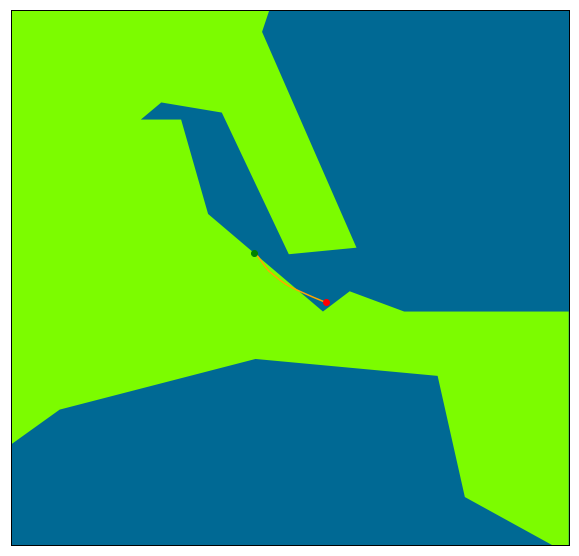

```python
fig = plt.figure(figsize=(10,10))
border_buff = 0.03   # space around the segment on the map

mapImage = Basemap(resolution = 'h',
            llcrnrlon=np.min(map_coordinates_df['Latitude'])-border_buff,
            llcrnrlat=np.min(map_coordinates_df['Longitude'])-border_buff,
            urcrnrlon=np.max(map_coordinates_df['Latitude'])+border_buff,
            urcrnrlat=np.max(map_coordinates_df['Longitude'])+border_buff)
mapImage.fillcontinents(color = '#7cfc00')  # fill in land with "lawn-green" hex colour
mapImage.drawmapboundary(fill_color='#006994') # fill in sea with "sea blue" hex colour


z=mapImage.plot(map_coordinates_df['Latitude'], map_coordinates_df['Longitude'], color='#FFA500', latlon=True)
x=mapImage.plot(map_coordinates_df['Latitude'].iloc[0], map_coordinates_df['Longitude'].iloc[0], color='g', marker = 'o', latlon=True)
y=mapImage.plot(map_coordinates_df['Latitude'].iloc[-1], map_coordinates_df['Longitude'].iloc[-1], color='r', marker = 'o',latlon=True)

plt.show()
```

A common visualisation of wind is using a Rose Petal graph. This shows the direction from which wind comes for a set of measurements. The length of the petal indicates how many measurements come from that direction. The colours of the petal indicate what proportion of those measurements were within the speed range defined in the legend.

This graph is first generated for all of the efforts under consideration. The graph is then regenerated for just the 20 fastest efforts.

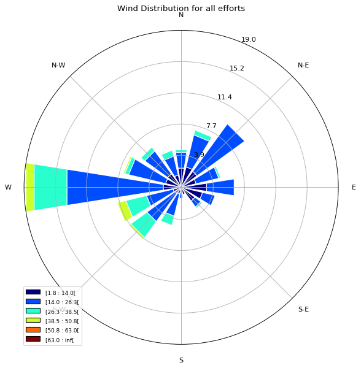

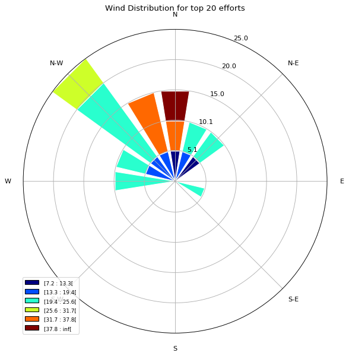

```python
def plotWind(df, title):
    ax = WindroseAxes.from_ax()   # windrose requires its own special axes and so can't be placed on subplot
    ax.bar(df.WindAngle, df.WindSpeed, normed=True, opening=0.8, edgecolor='white')
    ax.set_legend()
    ax.set_title(title)
    plt.show()

plotWind(weatherEfforts_df, 'Wind Distribution for all efforts')
plotWind(weatherEfforts_df.iloc[0:20], 'Wind Distribution for top 20 efforts')
```

The first graph shows a good distribution of wind directions for the efforts. A large amount of efforts were attempted in Westerly winds. This is as expected, as this West and South-West wind directions are the prevailant wind directions in Ireland. It is worth noting that attempts in South Westerly winds are somewhat under-represented on this segment despite this being a prevailing wind direction for this country. Perhaps this suggests that people will not travel in the direction of this segment along the exposed coast if they are expecting a headwind.

The second plot shows the distribution of wind speeds and directions for the fastest 20 attemps. This shows that winds which in general are quite rare for attempts on this segment truly dominate the top 20 attempts. This is particularly apparent in the NW direction, which has relatively few attempts overall, but has by far the largest proportion of attempts in the top 20. Refering to the map of the segment above shows that this direction aligns perfectly with the direction of the segment.

## Effect of Riding in a Group

First, let us obseve define an exceptional effort on this segment as breaking the 90 second mark. Let's look at the breakdown of exceptional efforts.

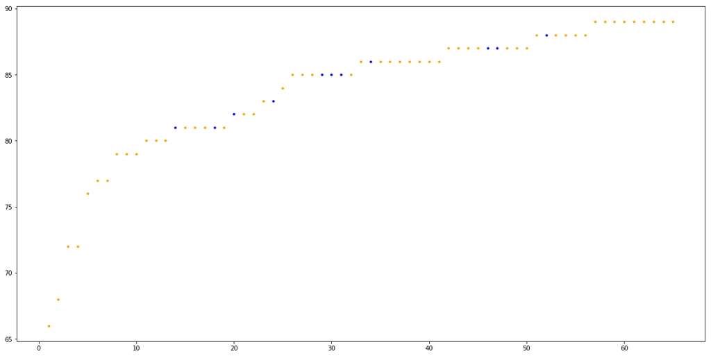

|  | Min | Mean |
| --- | --- | --- |
| Groups | 00:01:21 | 00:01:24.545454 |
| Solo | 00:01:06 | 00:01:23.666666 |

```python
fig = plt.figure(figsize=(20,10))     # create figure which is an appropriate size

# create data frames out of the group and solo DFs, which will just contain efforts below the 90s threshold.
fast_groups= group_efforts[group_efforts['ElapsedTime'] < datetime.timedelta(seconds=90)]
fast_solos= solo_efforts[solo_efforts['ElapsedTime'] < datetime.timedelta(seconds=90)]


plt.scatter(fast_groups.index.values,fast_groups['ElapsedTime'].astype('timedelta64[s]'), color='b', marker='.')
plt.scatter(fast_solos.index.values,fast_solos['ElapsedTime'].astype('timedelta64[s]'), color='#FFA500', marker='.')
plt.show()

group_data = {'Min':fast_groups['ElapsedTime'].min(), 'Mean':fast_groups['ElapsedTime'].mean()}
solo_data = {'Min':fast_solos['ElapsedTime'].min(), 'Mean':fast_solos['ElapsedTime'].mean()}

pd.DataFrame(index=['Groups', 'Solo'], columns=['Min', 'Mean'], data=[group_data, solo_data])
```

Clearly, solo efforts have a monopoly on the top 10 efforts on this segment, and represent a significant proportion of the other efforts with a time less than 90 seconds. However, the mean figures are very similar, due to fewer extreme times by groups. This may be because groups are more consistent, however when acting alone, individauals are given the capability to give their 100% effort without being held back by others.

Solo efforts are also slightly over-represented in the efforts that broke the 90 scond mark, although the proportions are quite close compared to the breakdown in the total number of efforts.

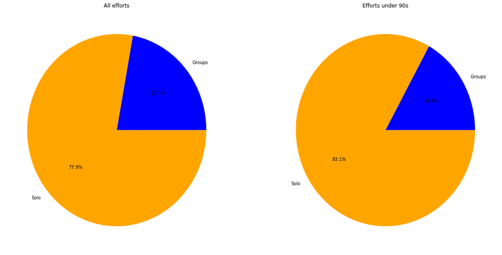

```python
def createPieChart(data1, data2, ax, title):
    # create pie chart with colours that match the colours used above.
    ax.pie([data1, data2], labels=['Groups', 'Solo'], autopct='%1.1f%%', colors=['b', '#FFA500'])
    ax.set_title(title)


fig, axarr = plt.subplots(nrows=1, ncols=2, figsize=(20,10))
createPieChart(fast_groups['ElapsedTime'].count(), fast_solos['ElapsedTime'].count(), axarr[1],'Efforts under 90s')
createPieChart(group_efforts['ElapsedTime'].count(), solo_efforts['ElapsedTime'].count(), axarr[0],'All efforts')
plt.show()
```

The above results show that cyclists on their can cover this segment in a quicker time than those in groups. Anyone familiar with the aerodynamic effects that cyclists can benefit from when riding with a group would find this very surprising. We shall now explore the data further to try to find the reason for these results.

It has been shown above that particular wind conditions dominate the top places on the leaderboard. Let's compare the wind conditions faced by the cyclists who achieved exceptional results on this segment.

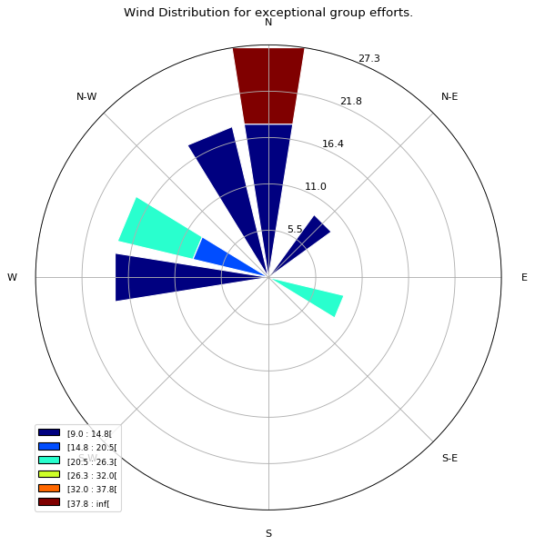

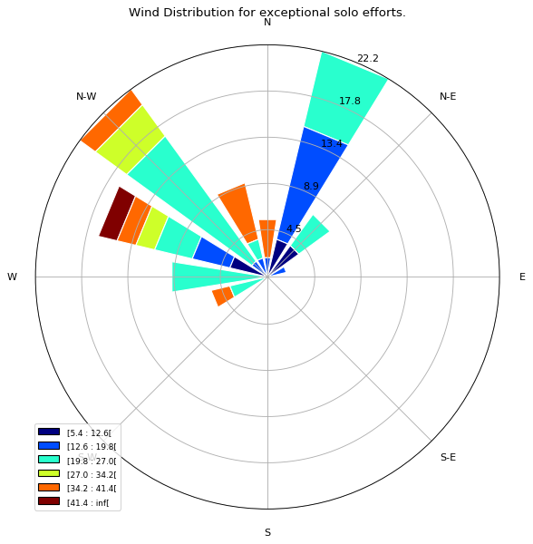

```python
plotWind(fast_groups, 'Wind Distribution for exceptional group efforts.')
plotWind(fast_solos, 'Wind Distribution for exceptional solo efforts.')
```

There are two main observations that may be made from this data. The first is that no groups enjoyed a North West wind which directly matches the direction of the segment, while many solo cyclists did. It is also clear that most group efforts also enjoyed less favourable wind speeds.

This is not due to a weather conspiracy against groups of cyclists. Indeed, I do not believe this is due to conincidence either. Lets take a look at a time distribution of when efforts are made on this segment.

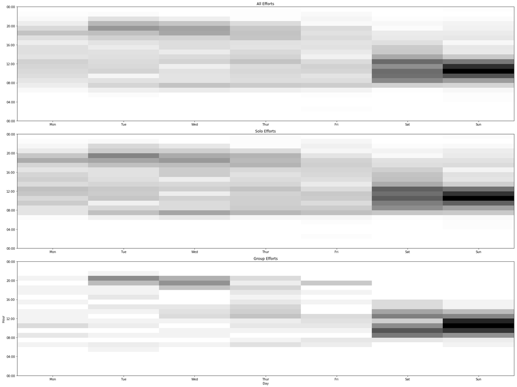

```python
# function that takes a dataframe of efforts and creates the values to be plotted in a heatmap
def heatmapColours(df):
    hours = range(24)       # hours of the day
    dayNames = range(7)      # days of the week

    # set x and y to show data for each time slot. Showing N values requires N+1 positions in the mesh-grid.
    x, y = np.meshgrid(np.concatenate((dayNames, [dayNames[-1]+1])), np.concatenate((hours, [hours[-1]+1])))
    # initialise colours array with 0 for each position.
    colours = np.array([[0 for w in range(len(dayNames))] for z in hours])
    #coloursSH = np.reshape(df.values,(len(hours), len(dayNames))).swapaxes(0,1)

    # turn the two value for each column into a 2D array
    i,j,= 0,0              # initialise counters
    for day in dayNames:   # for every day
        for hour in hours: # for each hour in that day
            # transfer the value in the DF into the 2D array
            colours[j,i] = df.loc[(day, hour), 'NumEfforts']
            j+=1
        i+=1
        j=0

    return x,y,colours

def heatmap(df, axes, title):
    x,y,colours = heatmapColours(df)
    cmap_style = cm.get_cmap('binary')  # use perceptually uniform color map
    axes.pcolormesh(x, y, colours, cmap=cmap_style)
    plt.xlabel('Day')
    plt.ylabel('Hour')
    axes.set_xticks(np.array([x-0.5 for x in range(1,8)]))
    x_labels = ['Mon', 'Tue', 'Wed', 'Thur', 'Fri', 'Sat', 'Sun']
    y_labels = ['00:00', '04:00', '08:00', '12:00', '16:00', '20:00', '00:00']
    axes.set_xticklabels(x_labels)
    axes.set_yticks([0,4,8,12,16,20,24])
    axes.set_yticklabels(y_labels)
    axes.set_title(title)
    plt.tight_layout()
    #plt.show()
    #return plt

fig, axarr = plt.subplots(nrows=3, ncols=1, figsize=(24,18))
heatmap(group_efforts_perHour, axarr[2],'Group Efforts')
heatmap(solo_efforts_perHour, axarr[1],'Solo Efforts')
heatmap(HourAndDayGroup, axarr[0], 'All Efforts')
plt.show()
```

These plots show that Sunday morning and early-midweek evenings are the most popular times on this segment. Groups seem to stick relatively strictly to these times, however there are far more light sections in the solo efforts heatmap. This suggests that groups are constrained to particular meet-up times, while solo cyclists can ride whenever they want.

Apply the same function to just the exceptional efforts gives the following heatmaps:

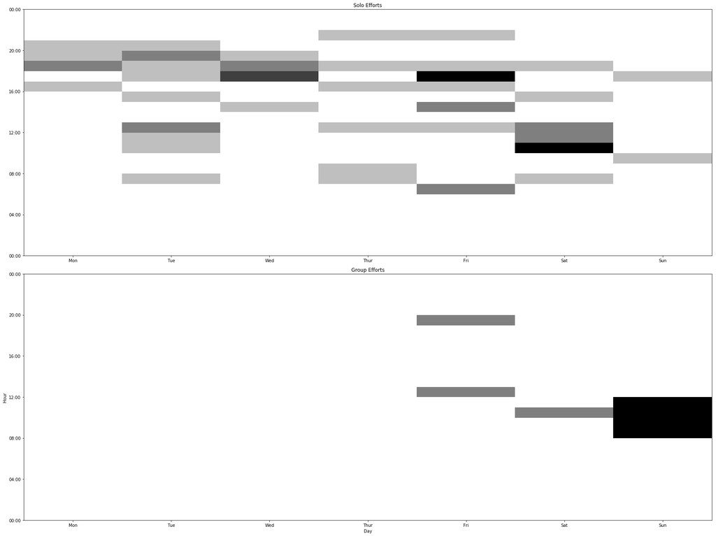

```python
fig, axarr = plt.subplots(nrows=2, ncols=1, figsize=(24,18))
heatmap(createHourAndDayGroups(fast_solos), axarr[0],'Solo Efforts')
heatmap(createHourAndDayGroups(fast_groups), axarr[1],'Group Efforts')
plt.show()
```

# Conclusions

The results above show that the fastest times on this Strava leaderboard are dominated by efforts which benefited from highly favourable wind conditions. It was found that solo cyclists performed better than group cyclists. This is not because being alone is faster than being in a group, but rather the results suggest that the increased flexibility of riding alone allows solo cyclists to better capitalise on opportune weather conditons, thus more than making up for the lost aerodynamic benefits while cycling alone.

Based on the results of this project, the advise to any cyclists aiming to record an exceptional time on this segment would be to wait for a favourable wind, and to make the most of it while its optimal rather than waiting from help from a group.